# Лабораторна робота № 6

## Конвеєр інтелектуального аналізу даних та інтерпретація моделі

**Інтелектуальний аналіз та візуалізація даних** · 4 години · 4 бали

### Постановка

Ви — аналітик інтернет-провайдера. Маркетинг просить модель, яка **в момент звернення клієнта** оцінює ризик, що той розірве договір протягом кварталу. Модель потрібна не заради числа: за її підказкою відділ утримання телефонуватиме людям і пропонуватиме знижку. Тому від вас хочуть **дві речі**:

1. чесну оцінку якості;
2. **пояснення**, чому модель вважає конкретного клієнта ризиковим.

Вам видали вивантаження з CRM. Воно зроблене не для аналізу, а для звітності, тому в ньому є все підряд — зокрема й те, чого в момент прогнозу ще не існує.

> **Попередження, яке варто прочитати двічі.** Перший результат, який ви отримаєте, буде прекрасним. Робота полягає в тому, щоб з'ясувати, чому йому не можна вірити, і скільки залишиться після того, як ви приберете все зайве.

### Що здаєте

Цей ноутбук із заповненими комірками, виконаними **згори вниз без помилок**, і відповідями на питання розділу 16.

### Як оцінюється

| Частина | Що оцінюється | Балів |
| --- | --- | --- |
| 1 | Конвеєр: обробка, витік, чесне число, вибір методу | 2,0 |
| 2 | Інтерпретація: важливість, PDP, SHAP | 1,5 |
| 3 | Звіт: обґрунтування рішень і виявлені хибні інтерпретації | 0,5 |

Штраф −0,5 бала, якщо ноутбук не виконується згори вниз на чистому ядрі.

## 0. Ваш варіант

Впишіть прізвище та номер у списку групи. Файл даних підтягнеться сам.

```python
STUDENT_NAME = 'Бугай Софія Володимирівна'     # напр. 'Коваленко Іван Петрович'
LIST_NUMBER  = 2      # номер у списку групи

assert STUDENT_NAME and LIST_NUMBER > 0, 'впишіть прізвище та номер у списку'
VARIANT = (LIST_NUMBER - 1) % 30 + 1
DATA = 'lr6_варіант_%02d.csv' % VARIANT
print('варіант %d, файл %s' % (VARIANT, DATA))
```

```
варіант 2, файл lr6_варіант_02.csv
```

> Файли варіантів лежать у теці `дані/` поряд із ноутбуком. Якщо викладач призначив вам інший варіант — перепишіть `VARIANT` вручну і зазначте це у звіті.

```python
import importlib.util, subprocess, sys
REQUIRED = ['pandas', 'numpy', 'scikit-learn', 'matplotlib', 'shap']
MODNAME  = {'scikit-learn': 'sklearn'}
missing = [p for p in REQUIRED if importlib.util.find_spec(MODNAME.get(p, p)) is None]
if missing:
    print('встановлюю:', ', '.join(missing), '...')
    subprocess.check_call([sys.executable, '-m', 'pip', 'install', '-q', *missing])
print('усі пакети на місці')
```

```
усі пакети на місці
```

```python
import warnings; warnings.filterwarnings('ignore')
import os, re, json, time, datetime
import numpy as np
import pandas as pd
import matplotlib.pyplot as plt

from sklearn.base import clone
from sklearn.pipeline import Pipeline
from sklearn.compose import ColumnTransformer
from sklearn.impute import SimpleImputer
from sklearn.preprocessing import StandardScaler, OneHotEncoder
from sklearn.linear_model import LogisticRegression
from sklearn.ensemble import RandomForestClassifier, HistGradientBoostingClassifier
from sklearn.model_selection import (RepeatedStratifiedKFold, cross_val_score,
                                     train_test_split)
from sklearn.inspection import permutation_importance, partial_dependence
from sklearn.metrics import roc_auc_score, confusion_matrix, classification_report

SEED = 42
pd.set_option('display.width', 200)
pd.set_option('display.max_columns', 60)
print('усе імпортовано')
```

```
усе імпортовано
```

## 1. Три рішення, які ухвалюють ДО того, як торкнутись даних

Нагадування з лекції 7: кроки 1–3 алгоритму виконуються перш ніж ви напишете хоч один рядок обробки. Якщо обрати метрику після того, як побачив результати, ви оберете ту, яка показала більше.

### Завдання 1.1

Заповніть три змінні нижче і **обґрунтуйте кожну** одним реченням у коментарі.

```python
# ----- ВАШІ ВІДПОВІДІ -----

TYPE_OF_TASK = 'класифікація'      # 'класифікація' / 'регресія' / 'кластеризація' / 'зменшення розмірності'
# чому: Цільова змінна є бінарною - клієнт або розірве договір, або ні.

METRIC = 'AUC'            # 'точність' / 'AUC' / 'F1' / 'повнота' / 'MAE'
# чому саме ця, а не точність: AUC є більш інформативною метрикою для оцінки моделей класифікації,
# особливо коли маємо справу з незбалансованими класами. Вона дозволяє оцінити здатність моделі відокремлювати позитивні
# та негативні класи незалежно від порогу класифікації, що робить її більш надійною у випадках, коли точність може бути
# оманливою через дисбаланс у даних.

CV_SCHEME = 'стратифікована 5-кратна'         # напр. 'стратифікована 5-кратна, 4 повтори'
# чому саме така: У задачах класифікації з незбалансованими класами стандартне K-кратне розщеплення
# може не зберігати розподіл класів. Стратифікований K-фолд гарантує, що кожен склад має приблизно
# таку ж частку класів, як і загальний набір даних

for nme, val in [('TYPE_OF_TASK', TYPE_OF_TASK), ('METRIC', METRIC), ('CV_SCHEME', CV_SCHEME)]:
    assert val, 'не заповнено: ' + nme
print('рішення зафіксовані')
```

```
рішення зафіксовані
```

> **Підказка до METRIC.** Подивіться на частку відтоку в наступному розділі. Якщо вона далека від 50 %, подумайте, яку точність дасть модель «ніхто не піде» — і чи варта вона чогось.

## 2. Перший погляд на дані

### Завдання 2.1

Прочитайте файл і дайте відповідь на чотири питання: скільки рядків і стовпців, яка частка відтоку, скільки стовпців має невизначений тип, де найбільше пропусків.

```python
raw = pd.read_csv(os.path.join('дані', DATA), encoding='utf-8-sig')
TARGET = 'відтік'

print('розмір:', raw.shape)
print('частка відтоку: %.3f' % raw[TARGET].mean())
print()
print('типи стовпців:', raw.dtypes.astype(str).value_counts().to_dict())
```

```
розмір: (1200, 26)
частка відтоку: 0.280

типи стовпців: {'str': 14, 'float64': 7, 'int64': 5}
```

```python
# ----- ВАШ КОД: таблиця «стовпець | тип | унікальних | % пропусків | приклад» -----
summary = pd.DataFrame({
    'тип': raw.dtypes,
    'унікальних': raw.nunique(),
    '% пропусків': (raw.isna().mean() * 100).round(1),
    'приклад': raw.apply(lambda s: s.dropna().iloc[0] if s.notna().any() else None),
})

# Відсортуйте за часткою пропусків спадно і покажіть усі стовпці.
summary.index.name = 'стовпець'
summary = summary.sort_values('% пропусків', ascending=False)

display(summary)
```

| стовпець | тип | унікальних | % пропусків | приклад |
| --- | --- | --- | --- | --- |
| дата_розірвання | str | 278 | 72.0 | 2024-04-20 |
| код_причини_закриття | str | 5 | 72.0 | ЦІН-02 |
| середній_час_відповіді_хв | float64 | 263 | 35.8 | 13.8 |
| трафік_ГБ | str | 953 | 5.0 | 96.2 |
| щомісячний_платіж | str | 1122 | 4.0 | 304.94 |
| аварій_на_ділянці_за_квартал | float64 | 6 | 3.0 | 3.0 |
| стать | str | 6 | 0.0 | ж |
| місто | str | 6 | 0.0 | Самбір |
| id_клієнта | str | 1200 | 0.0 | K20000 |
| вік | float64 | 61 | 0.0 | 42.0 |
| кількість_послуг | int64 | 3 | 0.0 | 1 |
| автоплатіж | str | 2 | 0.0 | так |
| спосіб_оплати | str | 3 | 0.0 | картка |
| тип_підключення | str | 3 | 0.0 | оптика |
| тариф | str | 4 | 0.0 | Максимальний |
| філія | str | 6 | 0.0 | Ф-05 Північ |
| знижка_відсоток | int64 | 3 | 0.0 | 10 |
| швидкість_тарифу_Мбіт | int64 | 9 | 0.0 | 600 |
| кількість_звернень_у_підтримку | int64 | 7 | 0.0 | 0 |
| місяців_обслуговування | float64 | 79 | 0.0 | 19.0 |
| трафік_МБ | float64 | 1200 | 0.0 | 96808.8 |
| код_тарифного_плану | str | 40 | 0.0 | КОД-008 |
| дата_підключення | str | 599 | 0.0 | 2024-06-03 |
| індекс_лояльності_CRM | float64 | 1200 | 0.0 | 173.053 |
| оцінка_ризику_менеджером | float64 | 5 | 0.0 | 3.0 |
| відтік | int64 | 2 | 0.0 | 0 |

### Завдання 2.2 — три способи, якими дані вже зіпсовані

У вивантаженні є щонайменше три проблеми, кожна з яких тихо зламає модель. Знайдіть їх і **назвіть конкретні стовпці**.

1. Числова колонка, у якій частина значень записана **текстом**.
2. Колонка, у якій Excel перетворив число на **дату**.
3. Колонка, пропуски в якій **не випадкові** — їхня наявність сама щось означає (механізм MNAR за класифікацією Рубіна, розділ 7.2 конспекту).

```python
# ----- ВАШ КОД: знайдіть і покажіть по кілька прикладів кожної проблеми -----
import re

# 1. Числова колонка, у якій частина значень записана текстом
print("------ Перевірка числових колонок, де частина значень записана текстом -----")
obj_cols = raw.select_dtypes(exclude='number').columns

rows = []
for c in obj_cols:
    s = raw[c].dropna().astype(str).str.strip()
    cleaned = s.str.replace(r'[\s\u00a0]', '', regex=True).str.replace(',', '.', regex=False)
    cleaned = cleaned.str.replace(r'[^\d.\-eE]', '', regex=True)
    as_num = pd.to_numeric(cleaned, errors='coerce')
    share_num = as_num.notna().mean()
    if share_num > 0.5 and s.nunique() > 15:
        bad = s[pd.to_numeric(s, errors='coerce').isna()]
        rows.append((c, round(share_num, 2), bad.unique()[:5].tolist()))

for r in sorted(rows, key=lambda x: -x[1]):
    print(r)

# 2. Колонка, у якій Excel перетворив число на дату
print("\n------ Перевірка колонок, у яких Excel перетворив число на дату -----")
for c in obj_cols:
    s = raw[c].dropna().astype(str).str.strip()
    pat = r'^(\d{4}-\d{2}-\d{2}|\d{1,2}[./-]\d{1,2}[./-]\d{2,4}|\d{1,2}-[A-Za-zА-Яа-яІіЇїЄє]{3,})'
    share = s.str.match(pat).mean()
    if 0 < share < 1:
        print(c, round(share, 2), s[s.str.match(pat)].unique()[:5].tolist())

# 3. Колонка, пропуски в якій не випадкові
print("\n------ Перевірка колонок, пропуски в яких не випадкові -----")
target = 'відтік'
miss = raw.drop(columns=target).isna()
mn = pd.DataFrame({
    '% пропусків': (miss.mean() * 100).round(1),
    'відтік | є значення': raw[~miss].groupby(lambda i: 0).size() if False else None,
})
res = []
for c in miss.columns:
    if 0 < miss[c].mean() < 1:
        res.append((c,
                    round(miss[c].mean() * 100, 1),
                    round(raw.loc[miss[c], target].mean(), 3),
                    round(raw.loc[~miss[c], target].mean(), 3)))
out = pd.DataFrame(res, columns=['стовпець', '% пропусків', 'відтік за пропуску', 'відтік за наявності'])
out['різниця'] = (out['відтік за пропуску'] - out['відтік за наявності']).abs()
display(out.sort_values('різниця', ascending=False))
```

```
------ Перевірка числових колонок, де частина значень записана текстом -----
('id_клієнта', np.float64(1.0), ['K20000', 'K20001', 'K20002', 'K20003', 'K20004'])
('щомісячний_платіж', np.float64(1.0), ['210.63 грн', '384.39 грн', '266.78 грн', '289.64 грн', '268.59 грн'])
('трафік_ГБ', np.float64(1.0), ['1900-01-02 00:00:00', '1900-01-01 00:00:00'])
('код_тарифного_плану', np.float64(1.0), ['КОД-008', 'КОД-002', 'КОД-038', 'КОД-013', 'КОД-029'])

------ Перевірка колонок, у яких Excel перетворив число на дату -----
трафік_ГБ 0.0 ['1900-01-02 00:00:00', '1900-01-01 00:00:00']

------ Перевірка колонок, пропуски в яких не випадкові -----
```

|  | стовпець | % пропусків | відтік за пропуску | відтік за наявності | різниця |
| --- | --- | --- | --- | --- | --- |
| 4 | код_причини_закриття | 72.0 | 0.000 | 1.000 | 1.000 |
| 5 | дата_розірвання | 72.0 | 0.000 | 1.000 | 1.000 |
| 2 | аварій_на_ділянці_за_квартал | 3.0 | 0.417 | 0.276 | 0.141 |
| 3 | середній_час_відповіді_хв | 35.8 | 0.228 | 0.309 | 0.081 |
| 1 | трафік_ГБ | 5.0 | 0.267 | 0.281 | 0.014 |
| 0 | щомісячний_платіж | 4.0 | 0.271 | 0.280 | 0.009 |

```python
PROBLEM_TEXT_IN_NUMBER = 'щомісячний_платіж'    # назва стовпця
PROBLEM_EXCEL_DATE     = 'трафік_ГБ'    # назва стовпця
PROBLEM_MNAR           = 'код_причини_закриття'    # назва стовпця
MNAR_MEANING           = 'клієнти не розривали контракту'    # що означає сам факт пропуску, одним реченням

for nme, val in [('PROBLEM_TEXT_IN_NUMBER', PROBLEM_TEXT_IN_NUMBER),
                 ('PROBLEM_EXCEL_DATE', PROBLEM_EXCEL_DATE),
                 ('PROBLEM_MNAR', PROBLEM_MNAR), ('MNAR_MEANING', MNAR_MEANING)]:
    assert val, 'не заповнено: ' + nme
assert PROBLEM_TEXT_IN_NUMBER in raw.columns and PROBLEM_EXCEL_DATE in raw.columns
assert PROBLEM_MNAR in raw.columns
print('проблеми названо')
```

```
проблеми названо
```

## 3. Будуємо матрицю ознак

Перетворення сирої таблиці на матрицю `X` — це фаза 3 CRISP-DM. Усі рішення тут приймаються **явно** і записуються, бо потім їх доведеться захищати.

### Завдання 3.1

Допишіть `to_number` і `build_X`.

- `to_number` має витягати число з тексту `'350.5 грн'`, **не** перетворювати дату на число і повертати `NaN` там, де числа немає.
- `build_X` для кожного стовпця вирішує: число, категорія чи викинути. Дата підключення має стати **числом** (напр. порядковим номером дня) — інакше модель її не з'їсть.

```python
import re
import datetime

_NUM = re.compile(r'[-+]?\d+(?:[.,]\d+)?')
_ISO = re.compile(r'^\s*\d{4}-\d{2}-\d{2}')

def to_number(s):
    """Витягує число з колонки, де перемішані числа, текст і дати."""
    def one(v):
        # ----- ВАШ КОД -----
        # 1) None / NaN
        if v is None:
            return np.nan
        # 2) datetime / Timestamp -> брак, а не дані
        if isinstance(v, (datetime.datetime, datetime.date, pd.Timestamp)):
            return np.nan
        # 3) число (bool не вважаємо числом)
        if isinstance(v, (int, float, np.integer, np.floating)) and not isinstance(v, bool):
            return float(v)
        t = str(v).replace('\u00a0', ' ')
        # 4) текст -> перше число в ньому, інакше NaN
        if _ISO.match(t):
            return np.nan
        t = re.sub(r'(?<=\d)[ ](?=\d{3}\b)', '', t)
        m = _NUM.search(t)
        return np.nan if m is None else float(m.group().replace(',', '.'))
    return s.map(one)



# самоперевірка
_t = pd.Series([1, '350.5 грн', '2,75', datetime.datetime(1900, 1, 11), None, 'немає'])
_r = to_number(_t)
assert _r[0] == 1.0 and abs(_r[1] - 350.5) < 1e-9 and abs(_r[2] - 2.75) < 1e-9
assert np.isnan(_r[3]), 'дата має стати NaN, а не числом'
assert np.isnan(_r[4]) and np.isnan(_r[5])
print('to_number працює')
```

```
to_number працює
```

```python
DROP_ALWAYS = ['id_клієнта']   # ідентифікатор: нічого не пояснює, лише запам'ятовується

def parse_dt(s):
    d = pd.to_datetime(s, errors='coerce', format='ISO8601')
    if d.notna().mean() < 0.8:
        d = pd.to_datetime(s, errors='coerce', format='mixed', dayfirst=True)
    return d

def build_X(d, drop):
    """Сира таблиця -> матриця ознак. Категорії лишаємо типом category."""
    X = pd.DataFrame(index=d.index)
    log = []
    for c in d.columns:
        if c in drop or c == TARGET:
            continue
        s = d[c]
        n_unique = s.nunique()

        if pd.api.types.is_datetime64_any_dtype(s):
            kind = 'date'
        elif pd.api.types.is_numeric_dtype(s):
            kind = 'num'
        else:
            nn = s.dropna()
            as_dt = parse_dt(nn)
            if len(nn) and as_dt.notna().mean() > 0.8:
                kind = 'date'
            else:
                parsed = to_number(nn)
                if len(nn) and parsed.notna().mean() > 0.8:
                    kind = 'text_num'
                else:
                    kind = 'cat'

        if kind == 'date':
            dt = s if pd.api.types.is_datetime64_any_dtype(s) \
                else parse_dt(s)
            X[c] = (dt - dt.min()).dt.days.astype(float)
            action = 'число (день від мінімуму)'
        elif kind == 'num':
            X[c] = s.astype(float)
            action = 'float'
        elif kind == 'text_num':
            X[c] = to_number(s)
            action = 'текст -> число'
        else:
            X[c] = (s.astype('string').str.strip().str.lower()
                      .astype('category'))
            action = 'category'

        log.append({'стовпець': c, 'тип': kind, 'дія': action,
                    'унікальних': n_unique,
                    '% пропусків': round(s.isna().mean() * 100, 1)})
    return X, pd.DataFrame(log)


X_all, log = build_X(raw, DROP_ALWAYS)
y = raw[TARGET].astype(int)
print('матриця ознак:', X_all.shape)
print('категоріальних:', sum(str(X_all[c].dtype) == 'category' for c in X_all.columns))
display(log)
```

```
матриця ознак: (1200, 24)
категоріальних: 6
```

|  | стовпець | тип | дія | унікальних | % пропусків |
| --- | --- | --- | --- | --- | --- |
| 0 | вік | num | float | 61 | 0.0 |
| 1 | стать | cat | category | 6 | 0.0 |
| 2 | місто | cat | category | 6 | 0.0 |
| 3 | філія | text_num | текст -> число | 6 | 0.0 |
| 4 | тариф | cat | category | 4 | 0.0 |
| 5 | тип_підключення | cat | category | 3 | 0.0 |
| 6 | спосіб_оплати | cat | category | 3 | 0.0 |
| 7 | автоплатіж | cat | category | 2 | 0.0 |
| 8 | кількість_послуг | num | float | 3 | 0.0 |
| 9 | місяців_обслуговування | num | float | 79 | 0.0 |
| 10 | швидкість_тарифу_Мбіт | num | float | 9 | 0.0 |
| 11 | щомісячний_платіж | text_num | текст -> число | 1122 | 4.0 |
| 12 | знижка_відсоток | num | float | 3 | 0.0 |
| 13 | трафік_ГБ | text_num | текст -> число | 953 | 5.0 |
| 14 | кількість_звернень_у_підтримку | num | float | 7 | 0.0 |
| 15 | аварій_на_ділянці_за_квартал | num | float | 6 | 3.0 |
| 16 | середній_час_відповіді_хв | num | float | 263 | 35.8 |
| 17 | трафік_МБ | num | float | 1200 | 0.0 |
| 18 | код_тарифного_плану | text_num | текст -> число | 40 | 0.0 |
| 19 | індекс_лояльності_CRM | num | float | 1200 | 0.0 |
| 20 | дата_підключення | date | число (день від мінімуму) | 599 | 0.0 |
| 21 | код_причини_закриття | text_num | текст -> число | 5 | 72.0 |
| 22 | дата_розірвання | date | число (день від мінімуму) | 278 | 72.0 |
| 23 | оцінка_ризику_менеджером | num | float | 5 | 0.0 |

### Завдання 3.2 — конвеєр

Зберіть `make_pipe(X, clf)`: колонковий перетворювач (числові — медіана плюс стандартизація; категоріальні — мода плюс одиничне кодування) і модель.

> **Чому саме так.** Відповідь у розділі 10 конспекту: усе, що має `fit`, мусить опинитись **усередині** конвеєра, інакше крос-валідація бреше. Зверніть увагу на `handle_unknown='ignore'` — без нього модель упаде на категорії, якої не було в навчальній згортці.

```python
def make_pipe(X, clf):
    num_cols = X.select_dtypes(include='number').columns.tolist()
    cat_cols = [c for c in X.columns if c not in num_cols]

    num_pipe = Pipeline([
        ('imp', SimpleImputer(strategy='median')),
        ('sc',  StandardScaler()),
    ])
    cat_pipe = Pipeline([
        ('imp', SimpleImputer(strategy='most_frequent')),
        ('ohe', OneHotEncoder(handle_unknown='ignore', sparse_output=False)),
    ])

    prep = ColumnTransformer([
        ('num', num_pipe, num_cols),
        ('cat', cat_pipe, cat_cols),
    ])
    return Pipeline([('prep', prep), ('clf', clf)])


def logreg():
    return LogisticRegression(max_iter=3000, random_state=SEED)


cv = RepeatedStratifiedKFold(n_splits=5, n_repeats=4, random_state=SEED)

# самоперевірка: конвеєр має бути єдиним оцінювачем і переживати крос-валідацію
_p = make_pipe(X_all, logreg())
assert hasattr(_p, 'fit') and hasattr(_p, 'predict')
_s = cross_val_score(_p, X_all, y, cv=RepeatedStratifiedKFold(
    n_splits=5, n_repeats=1, random_state=SEED), scoring='roc_auc')
assert len(_s) == 5
print('конвеєр зібрано, пробний прогін AUC %.3f' % _s.mean())
```

```
конвеєр зібрано, пробний прогін AUC 0.972
```

## 4. Перший результат

Запустіть модель на **всьому, що є**, — саме так робить дев'ять аналітиків із десяти, коли їм дали вивантаження і попросили «подивитись, чи взагалі щось передбачається».

```python
t0 = time.time()
auc_naive = cross_val_score(make_pipe(X_all, logreg()), X_all, y, cv=cv, scoring='roc_auc')
print('ознак    : %d' % X_all.shape[1])
print('AUC      : %.3f ± %.3f' % (auc_naive.mean(), auc_naive.std()))
print('час      : %.1f c' % (time.time() - t0))
```

```
ознак    : 24
AUC      : 0.970 ± 0.006
час      : 1.1 c
```

### Завдання 4.1

Подивіться на число і на таблицю орієнтирів AUC з розділу 4.4 конспекту.

Запишіть у `FIRST_REACTION` одне речення: що саме це число означає і яка з двох причин високої AUC, найімовірніше, спрацювала.

```python
FIRST_REACTION = 'Точність моделі на вигляд занадто ідеальна, скоріш за все стався витік даних'
assert FIRST_REACTION, 'напишіть, що ви думаєте про це число'
print(FIRST_REACTION)
```

```
Точність моделі на вигляд занадто ідеальна, скоріш за все стався витік даних
```

## 5. Шукаємо витік

Чотири типи витоку (розділ 9.1 конспекту) і засіб проти кожного:

| Тип | Засіб |
| --- | --- |
| цільовий | чек-ліст: чи існує значення в момент прогнозу |
| препроцесинговий | конвеєр |
| часовий | часова схема перевірки |
| груповий | групова схема перевірки |

Починаємо з цільового.

### Завдання 5.1 — автоматичний детектор

Напишіть `leak_scan`: для кожного стовпця перевірте, чи **сам факт заповненості** передбачає клас. Поріг `min_group` обов'язковий — без нього детектор видає хибні спрацювання на колонках, заповнених у двох клієнтів.

```python
def leak_scan(d, y, min_group=20):
    """Для кожного стовпця: наскільки добре його заповненість вгадує клас.

    Повертає таблицю зі стовпцями: ознака, заповнено, частка_відтоку_де_заповнено,
    частка_відтоку_де_пропуск, показник (0.5 = нічого, 1.0 = ідеальний поділ).
    """
    rows = []
    for c in d.columns:
        if c == TARGET:
            continue
        # ----- ВАШ КОД -----
        filled = d[c].notna()
        n_fill, n_miss = int(filled.sum()), int((~filled).sum())

        if n_fill < min_group or n_miss < min_group:
            continue

        score = roc_auc_score(y, filled.astype(int))
        rows.append({
            'ознака': c,
            'заповнено': n_fill,
            'частка_відтоку_де_заповнено': round(y[filled].mean(), 3),
            'частка_відтоку_де_пропуск': round(y[~filled].mean(), 3),
            'показник': round(score, 3),
        })
    return pd.DataFrame(rows).sort_values('показник', ascending=False)


scan = leak_scan(raw, y)
display(scan.head(10))
```

|  | ознака | заповнено | частка_відтоку_де_заповнено | частка_відтоку_де_пропуск | показник |
| --- | --- | --- | --- | --- | --- |
| 4 | код_причини_закриття | 336 | 1.000 | 0.000 | 1.000 |
| 5 | дата_розірвання | 336 | 1.000 | 0.000 | 1.000 |
| 3 | середній_час_відповіді_хв | 771 | 0.309 | 0.228 | 0.546 |
| 1 | трафік_ГБ | 1140 | 0.281 | 0.267 | 0.502 |
| 0 | щомісячний_платіж | 1152 | 0.280 | 0.271 | 0.501 |
| 2 | аварій_на_ділянці_за_квартал | 1164 | 0.276 | 0.417 | 0.490 |

### Завдання 5.2 — цільовий витік

Стовпці з показником близько 1,0 заповнені **лише в одного класу**. Такий стовпець записаний уже після того, як результат став відомий.

Випишіть їх у `TARGET_LEAK` і **для кожного поясніть одним реченням**, чому його не існує в момент прогнозу.

```python
TARGET_LEAK = [
    # 'назва_стовпця',   # чому його немає в момент прогнозу
    'дата_розірвання',     # з'являється лише тоді, коли договір уже розірвано, тобто після події, яку ми прогнозуємо
    'код_причини_закриття', # заповнюється при закритті договору, у чинного клієнта її не може бути
]
assert len(TARGET_LEAK) >= 2, 'таких стовпців більше ніж один'
assert all(c in raw.columns for c in TARGET_LEAK)
print('цільовий витік:', TARGET_LEAK)
```

```
цільовий витік: ['дата_розірвання', 'код_причини_закриття']
```

```python
X2, _ = build_X(raw, DROP_ALWAYS + TARGET_LEAK)
auc2 = cross_val_score(make_pipe(X2, logreg()), X2, y, cv=cv, scoring='roc_auc')
print('після вилучення цільового витоку: %d ознак, AUC %.3f ± %.3f'
      % (X2.shape[1], auc2.mean(), auc2.std()))
```

```
після вилучення цільового витоку: 22 ознак, AUC 0.967 ± 0.006
```

### Завдання 5.3 — витік, якого детектор НЕ бачить

Число майже не впало. Отже головне ще попереду.

Детектор знаходить колонки, **формально** пов'язані з ціллю. Він безсилий проти колонки, яка формально бездоганна, але якої **не існує в момент, коли ухвалюється рішення** — або яка означає не те, що здається.

Перегляньте решту стовпців **очима** і поставте кожному питання з розділу 9.3:

> **Чи міг я знати це значення в ту мить, коли треба ухвалити рішення?**

Нагадування про момент прогнозу: клієнт щойно зателефонував, договір **чинний**, рішення про знижку ухвалюється **зараз**.

```python
# ----- ВАШ КОД: перегляньте список стовпців, що лишились -----
print(list(X2.columns))
```

```
['вік', 'стать', 'місто', 'філія', 'тариф', 'тип_підключення', 'спосіб_оплати', 'автоплатіж', 'кількість_послуг', 'місяців_обслуговування', 'швидкість_тарифу_Мбіт', 'щомісячний_платіж', 'знижка_відсоток', 'трафік_ГБ', 'кількість_звернень_у_підтримку', 'аварій_на_ділянці_за_квартал', 'середній_час_ві…
```

```python
HUMAN_LEAK = [
    # 'назва_стовпця',   # ким і КОЛИ заповнюється це поле
    'оцінка_ризику_менеджером', # заповнює співробітник під час або після дзвінка, коли рішення вже ухвалене або майже ухвалене
]
HUMAN_LEAK_WHY = 'поле є висновком людини про цього клієнта, зробленим під час або після розмови, тому в момент ухвалення рішення воно ще не існує; детектор його не бачить, бо воно заповнене в усіх рядках, а проблема не в пропусках, а в моменті запису.'      # чому детектор із 5.1 його не спіймав

assert len(HUMAN_LEAK) >= 1 and HUMAN_LEAK_WHY
assert all(c in raw.columns for c in HUMAN_LEAK)
X3, _ = build_X(raw, DROP_ALWAYS + TARGET_LEAK + HUMAN_LEAK)
auc3 = cross_val_score(make_pipe(X3, logreg()), X3, y, cv=cv, scoring='roc_auc')
print('після вилучення оцінок людини: %d ознак, AUC %.3f ± %.3f'
      % (X3.shape[1], auc3.mean(), auc3.std()))
```

```
після вилучення оцінок людини: 21 ознак, AUC 0.854 ± 0.016
```

> Якщо тут число впало **суттєво** — ви знайшли головне. Якщо ні — перечитайте список стовпців ще раз: щось лишилось.

## 6. Артефакт збору даних

Лишилась найтонша перевірка. Якщо дані про два класи **збиралися по-різному** — у різні періоди, різними людьми, за різними правилами — модель вивчає спосіб запису, а не предмет. Жодна окрема колонка при цьому не є витоком; витоком є вся таблиця.

Обчислювана перевірка з розділу 9.3: спробувати передбачити **не ціль, а джерело**. Якщо за тими самими чесними ознаками добре вгадується філія або період підключення — класи не порівнянні між собою.

### Завдання 6.1 — частка відтоку за філіями і за періодом

| філія | клієнтів | частка_відтоку |
| --- | --- | --- |
| Ф-02 Захід | 190 | 0.468 |
| Ф-01 Центр | 191 | 0.440 |
| Ф-06 Приміська | 198 | 0.212 |
| Ф-05 Північ | 218 | 0.197 |
| Ф-03 Схід | 209 | 0.196 |
| Ф-04 Південь | 194 | 0.191 |

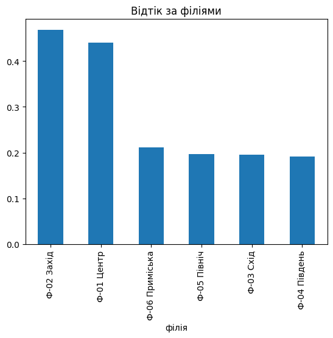

```python
# ----- ВАШ КОД -----
# 1) за філіями
by_branch = (raw.groupby('філія')[TARGET]
                .agg(клієнтів='size', частка_відтоку='mean')
                .round(3).sort_values('частка_відтоку', ascending=False))
display(by_branch)
by_branch['частка_відтоку'].plot(kind='bar', title='Відтік за філіями');
```

| квартал | клієнтів | частка_відтоку |
| --- | --- | --- |
| 2023Q1 | 149 | 0.342 |
| 2023Q2 | 144 | 0.278 |
| 2023Q3 | 157 | 0.287 |
| 2023Q4 | 172 | 0.297 |
| 2024Q1 | 136 | 0.257 |
| 2024Q2 | 126 | 0.246 |
| 2024Q3 | 160 | 0.256 |
| 2024Q4 | 156 | 0.269 |

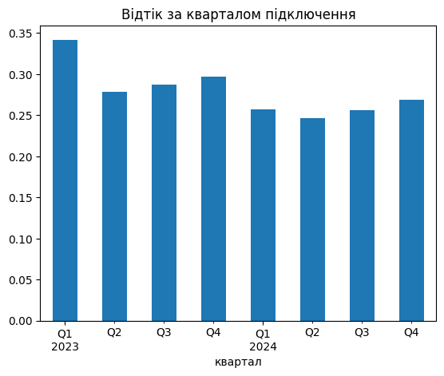

```python
# 2) за кварталами дати підключення
dt = parse_dt(raw['дата_підключення'])
by_q = (raw.assign(квартал=dt.dt.to_period('Q'))
           .groupby('квартал')[TARGET]
           .agg(клієнтів='size', частка_відтоку='mean')
           .round(3))
display(by_q)
by_q['частка_відтоку'].plot(kind='bar', title='Відтік за кварталом підключення');
# Шукайте СХОДИНКУ, а не плавну зміну.
```

### Завдання 6.2 — передбачити джерело

Візьміть **ті самі чесні ознаки**, що й для моделі відтоку, і спробуйте передбачити ними не `відтік`, а ознаку джерела: «клієнт із філії-підозрюваної» або «підключений після дати-зламу».

Якщо AUC помітно вища за 0,5 — у ваших даних закодоване джерело.

```python
SUSPECT = 'філія'        # 'філія' або 'дата_підключення' — що саме ви підозрюєте
assert SUSPECT in ('філія', 'дата_підключення')

# ----- ВАШ КОД: побудуйте бінарну змінну source -----
# для 'філія'          : 1 для філій із різко іншою часткою відтоку
# для 'дата_підключення': 1 для клієнтів, підключених після дати-зламу

rate = raw.groupby('філія')[TARGET].mean()
odd = rate[(rate - raw[TARGET].mean()).abs() > 0.1].index
source = raw['філія'].isin(odd).astype(int)


X4, _ = build_X(raw, DROP_ALWAYS + TARGET_LEAK + HUMAN_LEAK + [SUSPECT])
auc_src = cross_val_score(make_pipe(X4, logreg()), X4, source, cv=cv, scoring='roc_auc')
auc4 = cross_val_score(make_pipe(X4, logreg()), X4, y, cv=cv, scoring='roc_auc')
print('ті самі ознаки передбачають ДЖЕРЕЛО : AUC %.3f' % auc_src.mean())
print('ті самі ознаки передбачають ВІДТІК  : AUC %.3f ± %.3f' % (auc4.mean(), auc4.std()))
```

```
ті самі ознаки передбачають ДЖЕРЕЛО : AUC 0.660
ті самі ознаки передбачають ВІДТІК  : AUC 0.821 ± 0.025
```

### Завдання 6.3 — драбина

Зведіть усі чотири числа в одну таблицю і подивіться, **де саме** впало.

```python
ladder = pd.DataFrame([
    {'крок': '1. усе підряд',               'ознак': X_all.shape[1], 'AUC': auc_naive.mean()},
    {'крок': '2. мінус цільовий витік',     'ознак': X2.shape[1],    'AUC': auc2.mean()},
    {'крок': '3. мінус оцінки людини',      'ознак': X3.shape[1],    'AUC': auc3.mean()},
    {'крок': '4. мінус артефакт збору',     'ознак': X4.shape[1],    'AUC': auc4.mean()},
]).set_index('крок').round(3)
display(ladder)

HONEST_AUC = float(auc4.mean())
print('чесне число: %.3f ± %.3f' % (HONEST_AUC, auc4.std()))
```

| крок | ознак | AUC |
| --- | --- | --- |
| 1. усе підряд | 24 | 0.970 |
| 2. мінус цільовий витік | 22 | 0.967 |
| 3. мінус оцінки людини | 21 | 0.854 |
| 4. мінус артефакт збору | 20 | 0.821 |

```
чесне число: 0.821 ± 0.025
```

### Завдання 6.4

Чи **правильно** викидати підозрюваний стовпець? Це не риторичне питання: філія або дата підключення цілком можуть нести справжній сигнал (щільна забудова, нові тарифи), а не лише артефакт.

Запишіть своє рішення і аргумент. Обидві відповіді приймаються — оцінюється аргумент, а не вибір.

```python
DECISION_ARTEFACT = 'залишити, але звітувати окремо'    # 'викинути' / 'залишити' / 'залишити, але звітувати окремо'
DECISION_WHY = 'філія може нести справжній сигнал (якість мережі, щільність забудови, нові тарифи), а не лише відмінність у збиранні даних, тому викидати її наосліп означає втратити корисну інформацію; проте оцінку без неї і з ними треба показати окремо, бо різниця між цими числами і є міра того, наскільки результат залежить від способу збору.'
assert DECISION_ARTEFACT and DECISION_WHY
print(DECISION_ARTEFACT, '—', DECISION_WHY)
```

```
залишити, але звітувати окремо — філія може нести справжній сигнал (якість мережі, щільність забудови, нові тарифи), а не лише відмінність у збиранні даних, тому викидати її наосліп означає втратити корисну інформацію; проте оцінку без неї і з ними треба показати окремо, бо різниця між цими числами …
```